# Applied Computational Methods for Social Sciences

Lecture 10: Shapefiles, Coordinate Systems, and Basic Mapping

Bogdan G. Popescu

bogdan.popescu@johncabot.edu

John Cabot University

## What You’ll Learn Today

1. Loading and mapping **shapefiles** for countries and subdivisions
2. **Vector file formats**: shapefile, GeoPackage, GeoJSON, geodatabases
3. The **`sf` package**: geometries (`sfg`), geometry columns (`sfc`), and layers (`sf`)
4. **EPSG codes** and coordinate reference systems in practice
5. Building point layers **from tables** and subsetting spatial data

By the end, you’ll be able to read, create, and map vector data in R.

## Introduction

We previously covered the fundamentals of Geographic Information Systems (GIS)

We also learned about https://gadm.org

This is a good website to download shapefiles for countries and subdivisions

## Introduction

Create a new folder for this week

Download again the shapefiles for the US and Italy and place them in a folder called data.

- https://gadm.org

## Mapping the US `USA_0`

```r
library(sf)
#"s2" is an enhancement of the "sf" package
#It allows one to complete spatial operations with data that is in geographic coordinate system (the coordinates are in degrees)
#However, having it enabled will take much longer computation time
sf_use_s2(FALSE)
library(ggplot2)
#Step1: Read country shape
usa_cntry <- st_read(dsn="./data/gadm41_USA_shp/gadm41_USA_0.shp", quiet = TRUE)

#Step2: Simplify lines
usa_cntry<-st_simplify(usa_cntry,  dTolerance = 0.05)

#Define zoom
min_lon_x_us<-(-130)
max_lon_x_us<-(-57)
min_lat_y_us<-(26)
max_lat_y_us<-(53)

#Map
fig<-ggplot()+
  geom_sf(data=usa_cntry, linewidth = 0.3, fill = NA)+
  theme_bw()+
  coord_sf(xlim = c(min_lon_x_us-3, max_lon_x_us+3),
           ylim = c(min_lat_y_us-3, max_lat_y_us+3))
```

## Mapping the US `USA_0`

```r
fig
```

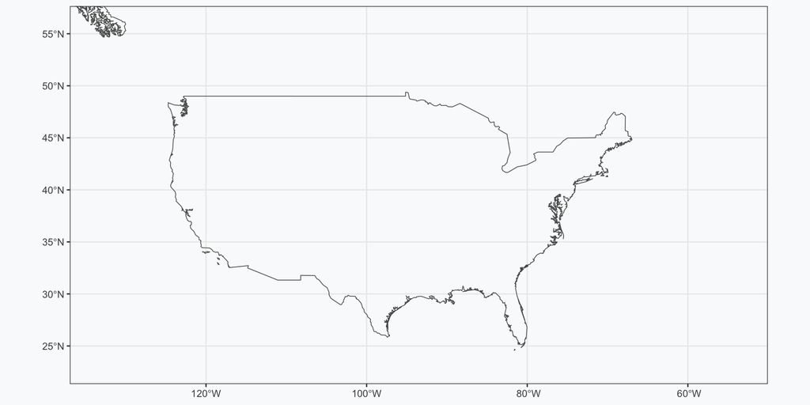

## Mapping the US `USA_0`

Let us examine what the dataframe looks like

```r
head(usa_cntry, 2)
```

```
Simple feature collection with 1 feature and 2 fields
Geometry type: MULTIPOLYGON
Dimension:     XY
Bounding box:  xmin: -178.9911 ymin: 18.91028 xmax: 179.7485 ymax: 71.33542
Geodetic CRS:  WGS 84
  GID_0       COUNTRY                       geometry
1   USA United States MULTIPOLYGON (((179.6461 52...
```

## Mapping the US `USA_0`

This is how we turn the `sf` object into a simple dataframe

```r
usa_cntry_df<-st_drop_geometry(usa_cntry)
head(usa_cntry_df, 2)
```

```
  GID_0       COUNTRY
1   USA United States
```

The two objects are very similar.

The difference is that `usa_cntry` has a geometry column. `usa_cntry_df` does not.

## Mapping the US `USA_0`

We can see the difference better if we do:

```r
class(usa_cntry)
```

```
[1] "sf"         "data.frame"
```

or

```r
class(usa_cntry_df)
```

```
[1] "data.frame"
```

## Shapefiles for Subdivisions of the US `USA_1`

```r
#Step1: Read country borders
usa_cntry1 <- st_read(dsn="./data/gadm41_USA_shp/gadm41_USA_1.shp", quiet = TRUE)

#Step2: Simplify lines
usa_cntry1<-st_simplify(usa_cntry1,  dTolerance = 0.05)

#Step3: Map
fig<-ggplot()+
  geom_sf(data=usa_cntry1, linewidth = 0.3, fill = NA)+
  theme_bw()+
  coord_sf(xlim = c(min_lon_x_us-3, max_lon_x_us+3),
           ylim = c(min_lat_y_us-3, max_lat_y_us+3))
```

## Shapefiles for Subdivisions of the US

```r
fig
```

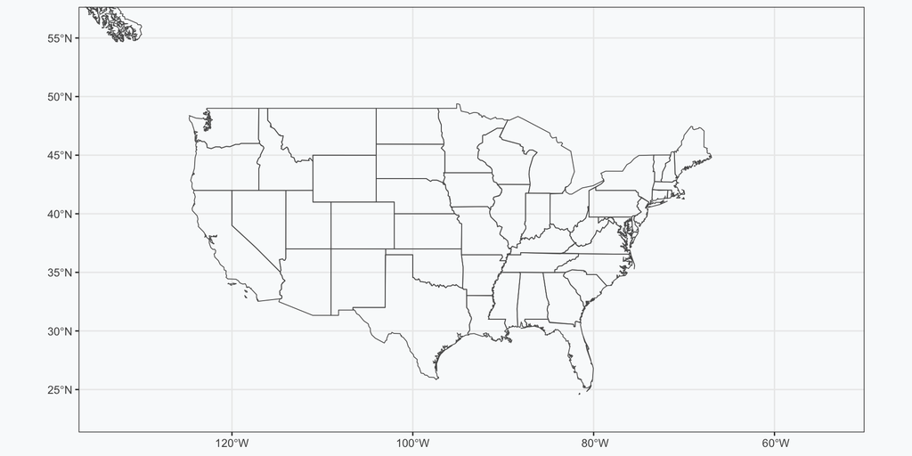

## Shapefiles for Subdivisions of the US `USA_2`

```r
#Step1: Read country borders
usa_cntry2 <- st_read(dsn="./data/gadm41_USA_shp/gadm41_USA_2.shp", quiet = TRUE)

#Step2: Simplify lines
usa_cntry2<-st_simplify(usa_cntry2,  dTolerance = 0.05)

#Step3: Map
fig<-ggplot()+
  geom_sf(data=usa_cntry2, linewidth = 0.3, fill = NA)+
  theme_bw()+
  coord_sf(xlim = c(min_lon_x_us-3, max_lon_x_us+3),
           ylim = c(min_lat_y_us-3, max_lat_y_us+3))
```

## Shapefiles for Subdivisions of the US `USA_2`

```r
fig
```

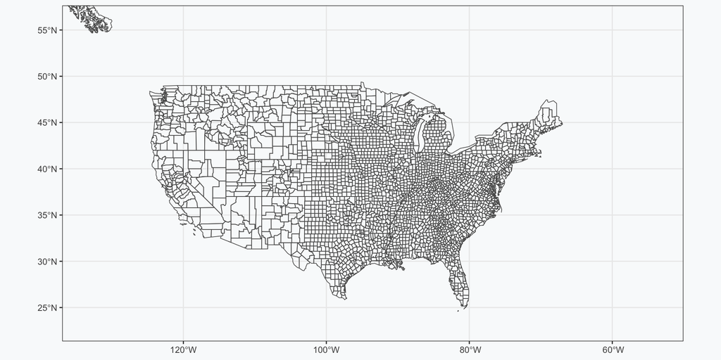

## Shapefiles for World

We can do the same for Italy

## Shapefiles for World `ITA_0`

```r
#Step1: Read country borders
it_cntry0 <- st_read(dsn="./data/gadm41_ITA_shp/gadm41_ITA_0.shp", quiet = TRUE)
it_cntry1 <- st_read(dsn="./data/gadm41_ITA_shp/gadm41_ITA_1.shp", quiet = TRUE)
it_cntry2 <- st_read(dsn="./data/gadm41_ITA_shp/gadm41_ITA_2.shp", quiet = TRUE)
it_cntry3 <- st_read(dsn="./data/gadm41_ITA_shp/gadm41_ITA_3.shp", quiet = TRUE)

#Step2: Simplify lines
it_cntry0<-st_simplify(it_cntry0,  dTolerance = 0.05)
it_cntry1<-st_simplify(it_cntry1,  dTolerance = 0.05)
it_cntry2<-st_simplify(it_cntry2,  dTolerance = 0.01)
it_cntry3<-st_simplify(it_cntry3,  dTolerance = 0.01)

#Step3: Map
fig<-ggplot()+
  geom_sf(data=it_cntry0, linewidth = 0.3, fill = NA)+
  theme_bw()
```

## Shapefiles for World `ITA_0`

```r
fig
```

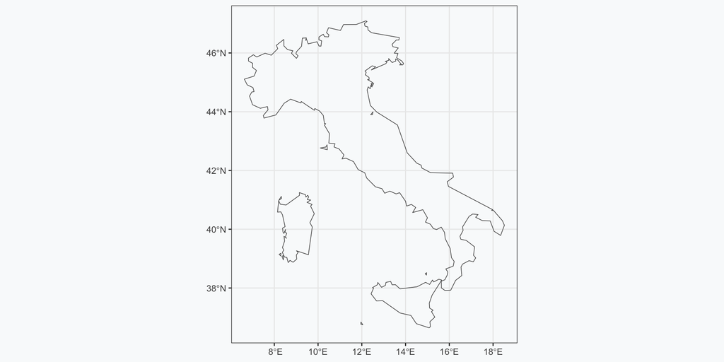

## Shapefiles for World `ITA_1`

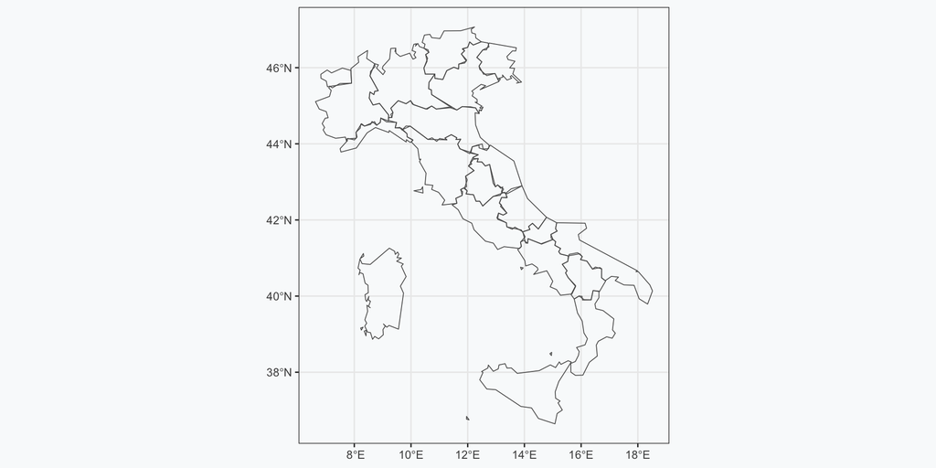

```r
#Step3: Map
fig<-ggplot()+
  geom_sf(data=it_cntry1, linewidth = 0.3, fill = NA)+
  theme_bw()
fig
```

## Shapefiles for World `ITA_1`

```r
#Step3: Map
fig
```

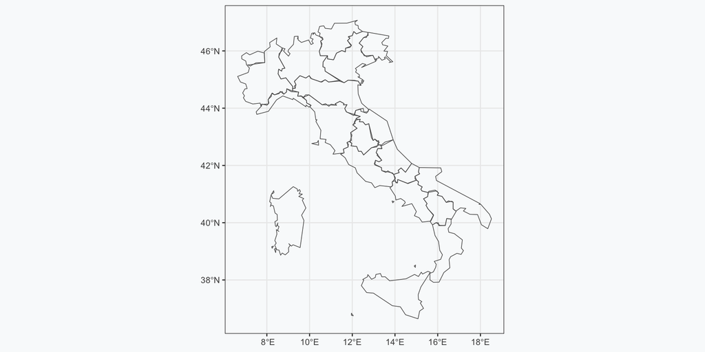

## Shapefiles for World `ITA_2`

```r
#Step3: Map
fig<-ggplot()+
  geom_sf(data=it_cntry2, linewidth = 0.3, fill = NA)+
  theme_bw()
```

## Shapefiles for World `ITA_2`

```r
fig
```

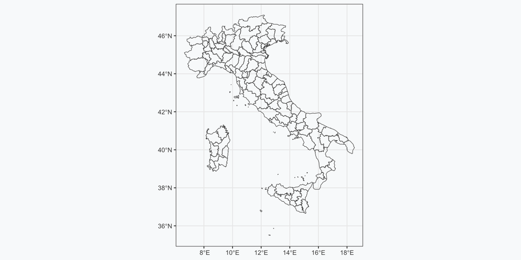

## Shapefiles for World `ITA_3`

```r
#Step3: Map
fig<-ggplot()+
  geom_sf(data=it_cntry3, linewidth = 0.05, fill = NA)+
  theme_bw()
```

## Shapefiles for World `ITA_3`

```r
fig
```

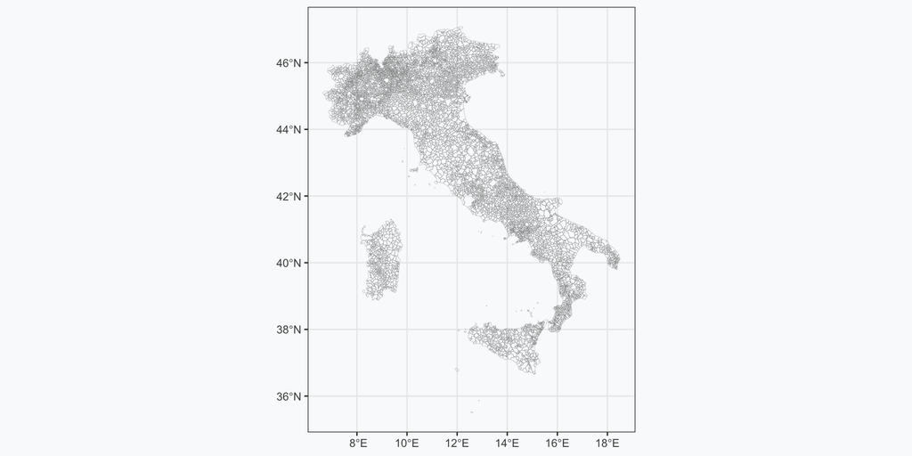

## Vector File Formats

The most common vector files are:

| **Type** | **Format** | **File extension** |
| --- | --- | --- |
| Binary | ESRI Shapefile | `.shp`, `.shx`, `.dbf`, `.prj` |
|  | GeoPackage (GPKG) | `.gpkg` |
| Plain Text | GeoJSON | `.json` or `.geojson` |
|  | GPS Exchange Format (GPX) | `.gpx` |
|  | Keyhole Markup Language (KML) | `.kml` |
| Spatial Databases | PostgreSQL / PostGIS |  |

## The `sp` package

- The first R package to establish a uniform vector layer class system was `sp` (2005-2023).
- Together with `rgdal` (2003-2023) and `rgeos` (2011-2023), the `sp` package dominated the landscape of spatial analysis in R

## Spatial Data Structures in `sp`

| **Class** | **Geometry type** | **Attributes** |
| --- | --- | --- |
| `SpatialPoints` | Points | - |
| `SpatialPointsDataFrame` | Points | `data.frame` |
| `SpatialLines` | Lines | - |
| `SpatialLinesDataFrame` | Lines | `data.frame` |
| `SpatialPolygons` | Polygons | - |
| `SpatialPolygonsDataFrame` | Polygons | `data.frame` |

## Caveat

- We will avoid the use of `sp`, `rgdal`, and `rgeos` and focus on the `sf` package.
- The `rgdal` package is deprecated starting with 2023.
- You should avoid using those packages (i.e. you will get errors and maybe conflicts with other libraries).
- However, it is important to be aware of these packages, given how many forums, articles, and dependencies have been using them.

## The `sf` package

`sf` is the standard package for working with vector data in R.

It relies on external software components: **GDAL**, **GEOS**, and **PROJ**.

It contains three classes:

- `sfg` — a single geometry
- `sfc` - a geometry column: a set of `sfg` geometries with CRS information
- `sf` - a layer which is an `sfc` column inside a data frame with non-spatial attributes.

## The `sf` class

## Geometry

`sfg` is a single geometry which can be of multiple types

- `st_point`
- `st_multipoint`
- `st_linestring`
- `st_multilinestring`
- `st_polygon`
- `st_multipolygon`
- `st_geometrycollection`

## Geometry

The last type `GEOMETRYCOLLECTION` is rarely used

The Shapefile format does not support geometries of type GEOMETRYCOLLECTION

## Geometry - Points

Let us create one point:

```r
library(sf)
library(ggplot2)
pt1 = st_point(c(34.798443, 31.243288))
```

If we print the point, we get its WKT (Well-Known Text) representation

```r
print(pt1)
```

[output not shown]

If we examine the class definition, we get:

```r
class(pt1)
```

```
[1] "XY"    "POINT" "sfg"
```

## Geometry - Points

```r
class(pt1)
```

```
[1] "XY"    "POINT" "sfg"
```

- `XY` is the two-dimensional geometry of the point
- `POINT` is the geometry type (it could be `POINT`, `MULTIPOINT`, etc.)
- `sfg` is the general class (i.e. simple feature geometry)

## Geometry - Points

```r
plot(pt1)
```

[output not shown]

## Geometry - Polygon

This is how we create a polygon

```r
a <- st_polygon(list(cbind(c(0,0,7.5,7.5,0),c(0,-1,-1,0,0))))
```

If we print the polygon, we get its WKT representation

```r
print(a)
```

```
POLYGON ((0 0, 0 -1, 7.5 -1, 7.5 0, 0 0))
```

If we examine the class definition, we get:

```r
class(a)
```

```
[1] "XY"      "POLYGON" "sfg"
```

## Geometry - Polygon

This is what that polygon looks like:

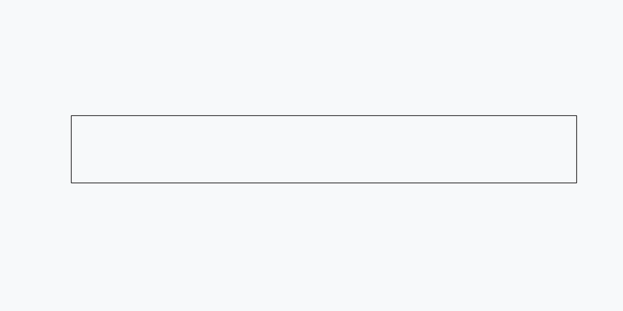

```r
plot(a)
```

## Geometry - Polygon

We can of course use `ggplot`

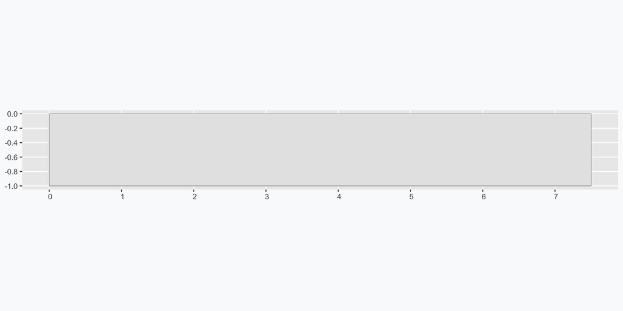

```r
a <- st_polygon(list(cbind(c(0,0,7.5,7.5,0),c(0,-1,-1,0,0))))
ggplot()+
  geom_sf(data=a)
```

## Geometry - Polygon 2

We can also make a more complicated polygon:

```r
b = st_polygon(list(cbind(c(0,1,2,3,4,5,6,7,7,0),c(1,0,0.5,0,0,0.5,-0.5,-0.5,1,1))))
print(b)
```

```
POLYGON ((0 1, 1 0, 2 0.5, 3 0, 4 0, 5 0.5, 6 -0.5, 7 -0.5, 7 1, 0 1))
```

This is what the class looks like:

```r
class(b)
```

```
[1] "XY"      "POLYGON" "sfg"
```

## Geometry - Polygon 2

This is what that polygon looks like:

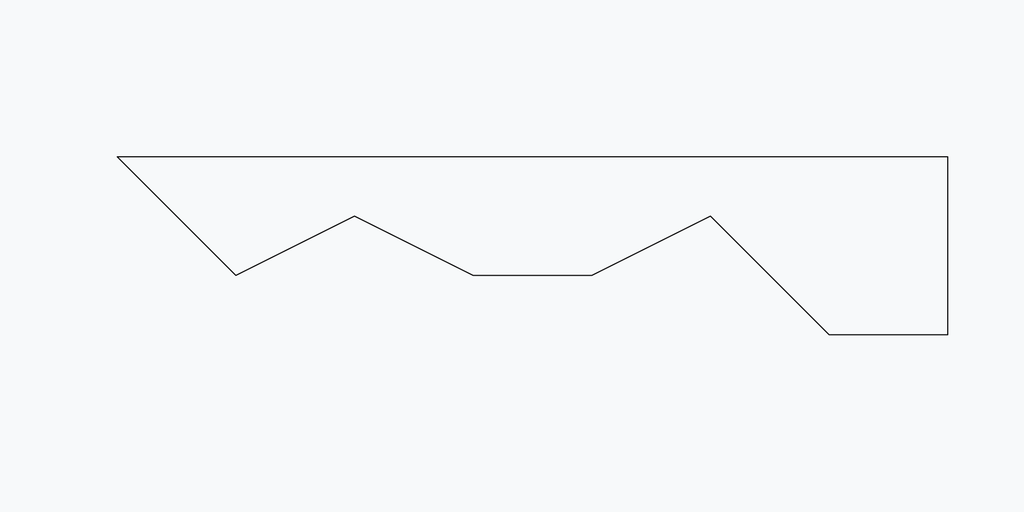

```r
plot(b)
```

## Combining Geometries

We can combine geometries using the `c` function

This will result in a single `MULTIPOLYGON` geometry, composed of all the shapes in the input

```r
ab <- c(a, b)
print(ab)
```

```
MULTIPOLYGON (((0 0, 0 -1, 7.5 -1, 7.5 0, 0 0)), ((0 1, 1 0, 2 0.5, 3 0, 4 0, 5 0.5, 6 -0.5, 7 -0.5, 7 1, 0 1)))
```

If we check the class of ab, we see that it is a `MULTIPOLYGON`

```r
class(ab)
```

```
[1] "XY"           "MULTIPOLYGON" "sfg"
```

## Combining Geometries

This is what the combined polygon looks like:

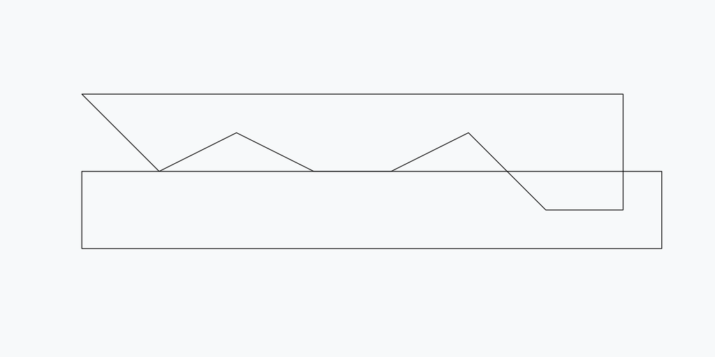

```r
plot(ab)
```

## Intersecting Geometries

A new geometry can be calculated by applying various functions to existing ones.

```r
i <- st_intersection(a, b)
print(i)
```

```
GEOMETRYCOLLECTION (POLYGON ((7 0, 7 -0.5, 6 -0.5, 5.5 0, 7 0)), LINESTRING (4 0, 3 0), POINT (1 0))
```

Notice the difference from the combined geometries: `ab`

```r
ab <- c(a, b)
print(ab)
```

```
MULTIPOLYGON (((0 0, 0 -1, 7.5 -1, 7.5 0, 0 0)), ((0 1, 1 0, 2 0.5, 3 0, 4 0, 5 0.5, 6 -0.5, 7 -0.5, 7 1, 0 1)))
```

## Intersecting Geometries

Also, notice the difference between classes:

```r
class(i)
```

```
[1] "XY"                 "GEOMETRYCOLLECTION" "sfg"
```

```r
class(ab)
```

```
[1] "XY"           "MULTIPOLYGON" "sfg"
```

## Intersecting Geometries

This is what the intersected geometries look like:

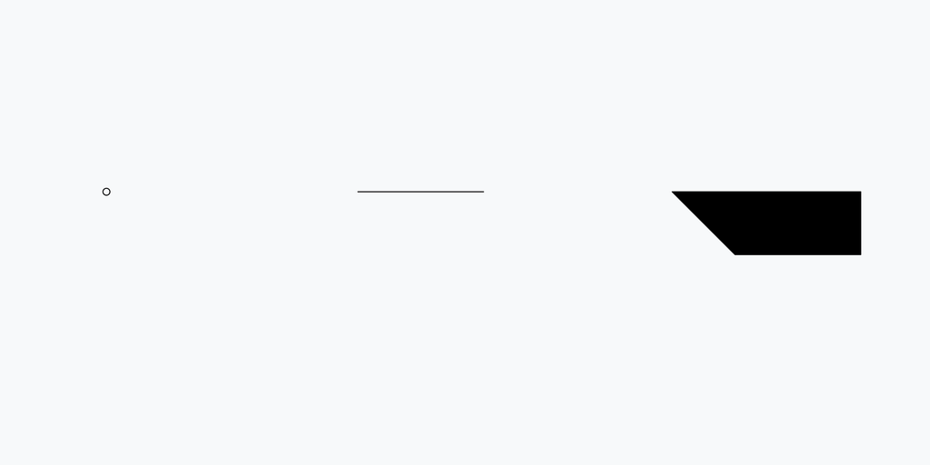

```r
i <- st_intersection(a, b)
plot(i)
```

## Intersecting Geometries

This is how they differ from the combined geometries:

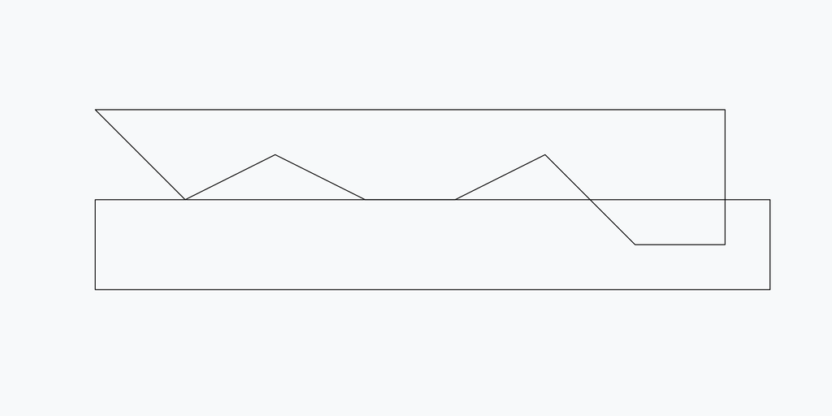

```r
ab <- c(a, b)
plot(ab)
```

## Geometry column - `sfc`

Let us create two more points: `pt2` and `pt3`.

```r
pt2 = st_point(c(34.812831, 31.260284))
pt3 = st_point(c(35.011635, 31.068616))
```

Geometry objects can be collected into a **geometry** column - `sfc`, which is done with `st_sfc`

A geometry column also contains a **Coordinate Reference System**

## Geometry column - `sfc`

Four types of CRS definitions are acceptable

- An **EPSG** code (e.g. `4326`)
- A `crs` object, as returned by the `st_crs` function
- A **PROJ4** string (e.g. `'+proj=longlat +datum=WGS84 +no_defs'`)
- A **WKT** string

If the crs argument is omitted, the default is to set an “undefined” CRS (i.e., NA).

## EPSG Codes

When you need precise measurements for things like distances, you should use EPSG codes.

EPSG Geodetic Parameter Dataset is a public registry of geodetic datums, spatial reference systems, Earth ellipsoids, coordinate transformations and related units of measurement.

It came from a member of the European Petroleum Survey Group in 1985.

Different countries have different codes.

## EPSG Codes

For example, the standard for the whole world is 4326, the equivalent of WGS84 (also used by Google)

The code for Italy is 6875.

This is from https://epsg.io

EPSG Geodetic Parameter Dataset is a public registry of geodetic datums, spatial reference systems.

## EPSG Codes

## EPSG Codes

## EPSG Codes

## EPSG Codes

## Geometry column - `sfc`

We can combine pt1, pt2, and pt3.

Reminder: this is how we defined them:

```r
pt1 = st_point(c(34.798443, 31.243288))
pt2 = st_point(c(34.812831, 31.260284))
pt3 = st_point(c(35.011635, 31.068616))
```

## Geometry column - `sfc`

This is how we combine them:

```r
combined <- st_sfc(pt1, pt2, pt3, crs = 4326)
combined
```

```
Geometry set for 3 features
Geometry type: POINT
Dimension:     XY
Bounding box:  xmin: 34.79844 ymin: 31.06862 xmax: 35.01164 ymax: 31.26028
Geodetic CRS:  WGS 84
```

```
POINT (34.79844 31.24329)
```

```
POINT (34.81283 31.26028)
```

```
POINT (35.01163 31.06862)
```

Note that we added 4326 - the code for the whole world.

## Geometry column - `sfc`

```r
plot(combined)
```

[output not shown]

Or

The combined points look like below

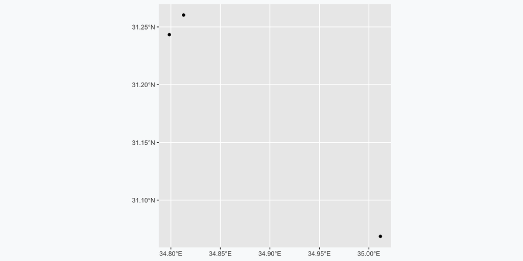

```r
ggplot()+
  geom_sf(data=combined)
```

## Layer `sf`

We can add attributes to the geometry in the following way:

```r
name<-c("Point 1", "Point 2", "Point 3")
name_df<-data.frame(name)
name_df
```

```
     name
1 Point 1
2 Point 2
3 Point 3
```

## Layer `sf`

We can combine the attribute table `name_df` and the geometry column geom (`sfc`) using `st_sf`, resulting in a layer

```r
layer <- st_sf(name_df, combined)
layer
```

```
Simple feature collection with 3 features and 1 field
Geometry type: POINT
Dimension:     XY
Bounding box:  xmin: 34.79844 ymin: 31.06862 xmax: 35.01164 ymax: 31.26028
Geodetic CRS:  WGS 84
     name                  combined
1 Point 1 POINT (34.79844 31.24329)
2 Point 2 POINT (34.81283 31.26028)
3 Point 3 POINT (35.01163 31.06862)
```

## Mapping the `sf` layer with `plot`

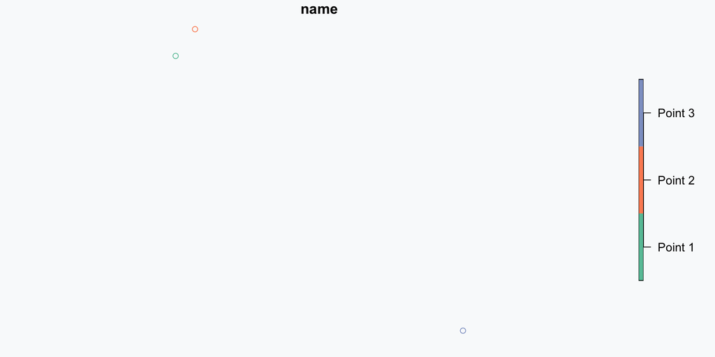

```r
plot(layer)
```

## Mapping the `sf` layer with `ggplot`

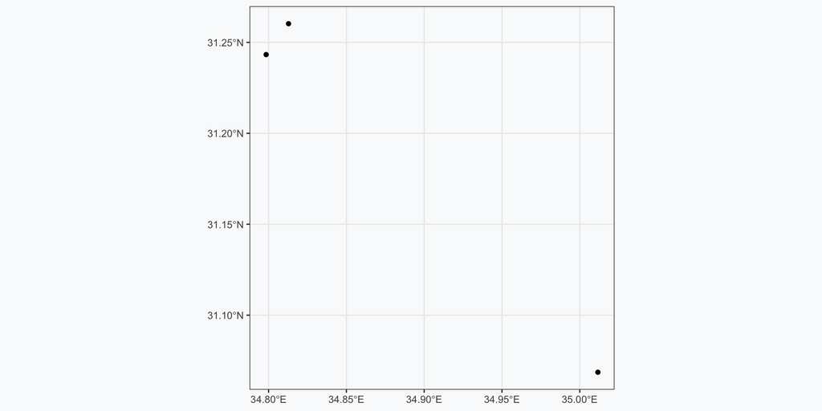

```r
ggplot()+
  geom_sf(data=layer)+ theme_bw()
```

## Mapping the `sf` layer with `ggplot`

We can also plot the polygons we made with `ggplot`

Here is what `ab` looks like:

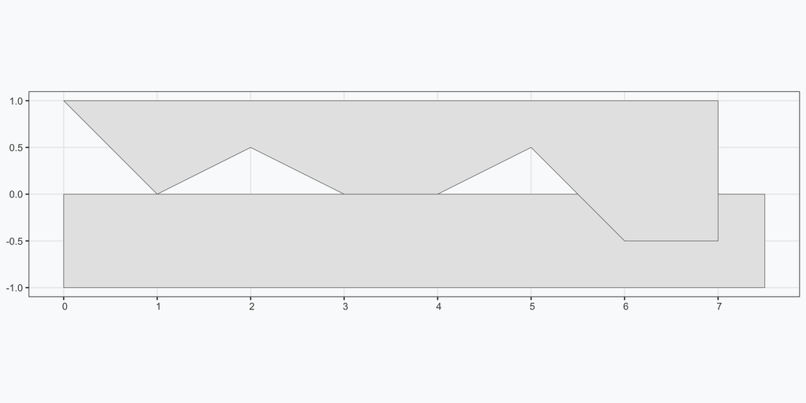

```r
ggplot()+
  geom_sf(data=ab)+ theme_bw()
```

## Extracting Layer Components

Sometimes, we are interested in going the other way around and extract:

- the geometry
- the attribute table
- the coordinates

## Extracting Layer Components: the Geometry

The following command allows us to extract the geometry

```r
st_geometry(layer)
```

```
Geometry set for 3 features
Geometry type: POINT
Dimension:     XY
Bounding box:  xmin: 34.79844 ymin: 31.06862 xmax: 35.01164 ymax: 31.26028
Geodetic CRS:  WGS 84
```

```
POINT (34.79844 31.24329)
```

```
POINT (34.81283 31.26028)
```

```
POINT (35.01163 31.06862)
```

## Extracting Layer Components: the Attribute Table

The following command allows us to drop the geometry

We are then left just with the attribute table:

```r
st_drop_geometry(layer)
```

```
     name
1 Point 1
2 Point 2
3 Point 3
```

## Extracting Layer Components: the Coordinates

The coordinates of `sf`, `sfc` or `sfg` objects can be obtained with the function `st_coordinates`.

The coordinates are a `matrix`:

```r
st_coordinates(layer)
```

```
            X        Y
[1,] 34.79844 31.24329
[2,] 34.81283 31.26028
[3,] 35.01163 31.06862
```

We can turn the matrix into a dataframe in the following way

```r
data.frame(st_coordinates(layer))
```

```
         X        Y
1 34.79844 31.24329
2 34.81283 31.26028
3 35.01163 31.06862
```

## Creating a Point Layer from a table

We can create point layers from tables.

Download the [Restaurants in Rome CSV file](https://www.dropbox.com/scl/fi/69tiv1w420iohrgjlrdkx/restaurants_rome.csv?rlkey=0jvxlv6grof5et6e4hjmq3iit&dl=0)

Place it in your week’s folder

## Creating a Point Layer from a table

We can create point layers from tables.

Here is an example below:

```r
df <- read.table("./data/restaurants_rome.csv", header = TRUE, sep = ",")
head(df, n=3)
```

```
                           name                 addr.street      lat      lon
1             Pizzeria ai Marmi         Viale di Trastevere 41.88826 12.47379
2                 Sichuan Haozi Via di San Martino ai Monti 41.89580 12.49948
3 Dar filettaro a Santa Barbara           Largo dei Librari 41.89467 12.47370
```

## Creating a Point Layer from a table

The restaurants dataframe can be converted to a sf layer using `st_as_sf`:

```r
df2 = st_as_sf(df, coords = c('lon', 'lat'))
st_crs(df2)<-st_crs(4326)
head(df2, n=2)
```

```
Simple feature collection with 2 features and 2 fields
Geometry type: POINT
Dimension:     XY
Bounding box:  xmin: 12.47379 ymin: 41.88826 xmax: 12.49948 ymax: 41.8958
Geodetic CRS:  WGS 84
               name                 addr.street                  geometry
1 Pizzeria ai Marmi         Viale di Trastevere POINT (12.47379 41.88826)
2     Sichuan Haozi Via di San Martino ai Monti  POINT (12.49948 41.8958)
```

## Creating a Point Layer from a table

This is what these points look like, if we map them out:

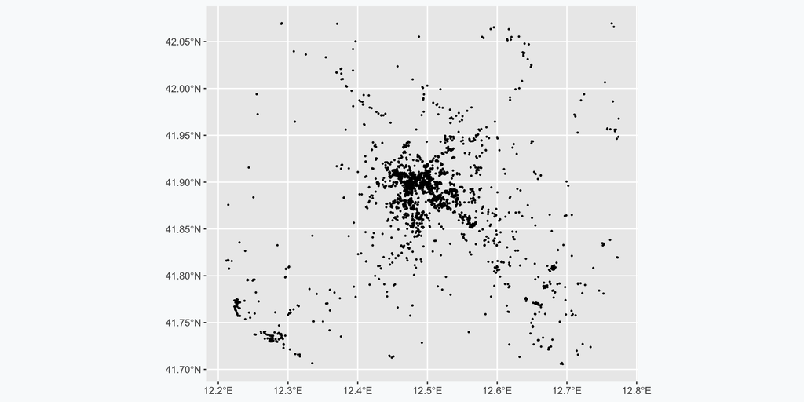

```r
ggplot()+
  geom_sf(data=df2, size=0.3)
```

## Creating a Point Layer from a table

Without some context, it is difficult to see what those points represent

You can see below an updated map with the streets in the background.

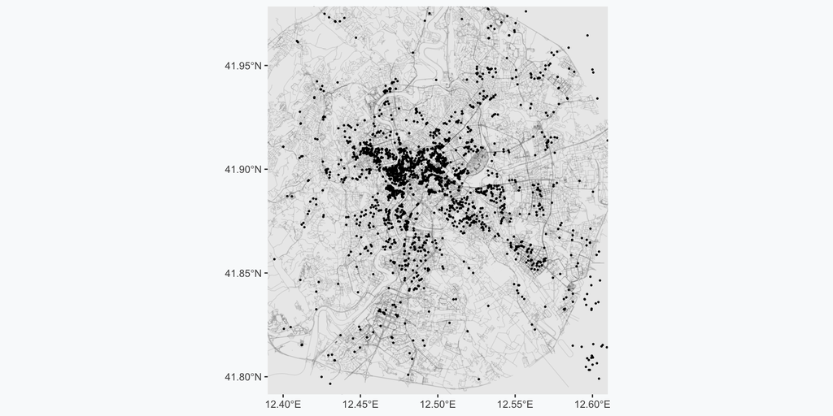

## `sf` properties: rows and columns

Some important properties of `sf` objects include rows and columns.

Number of rows:

```r
nrow(df2)
```

```
[1] 2811
```

Number of columns:

```r
ncol(df2)
```

```
[1] 3
```

We can obtain both rows and column by typing:

```r
dim(df2)
```

```
[1] 2811    3
```

## `sf` properties: bounding box coordinates

The `st_bbox` function returns the bounding box coordinates

```r
st_bbox(df2)
```

```
    xmin     ymin     xmax     ymax
12.21167 41.70574 12.77428 42.06974
```

This is helpful to find the extreme locations in our dataset: Northern-most, Southern-most, Eastern-most, Western-most

## `sf` properties: crs

The `st_crs` function returns the Coordinate Reference System (CRS)

```r
st_crs(df2)
```

```
Coordinate Reference System:
  User input: EPSG:4326
  wkt:
GEOGCRS["WGS 84",
    ENSEMBLE["World Geodetic System 1984 ensemble",
        MEMBER["World Geodetic System 1984 (Transit)"],
        MEMBER["World Geodetic System 1984 (G730)"],
        MEMBER["World Geodetic System 1984 (G873)"],
        MEMBER["World Geodetic System 1984 (G1150)"],
        MEMBER["World Geodetic System 1984 (G1674)"],
        MEMBER["World Geodetic System 1984 (G1762)"],
        MEMBER["World Geodetic System 1984 (G2139)"],
        MEMBER["World Geodetic System 1984 (G2296)"],
        ELLIPSOID["WGS 84",6378137,298.257223563,
            LENGTHUNIT["metre",1]],
        ENSEMBLEACCURACY[2.0]],
    PRIMEM["Greenwich",0,
        ANGLEUNIT["degree",0.0174532925199433]],
    CS[ellipsoidal,2],
        AXIS["geodetic latitude (Lat)",north,
            ORDER[1],
            ANGLEUNIT["degree",0.0174532925199433]],
        AXIS["geodetic longitude (Lon)",east,
            ORDER[2],
            ANGLEUNIT["degree",0.0174532925199433]],
    USAGE[
        SCOPE["Horizontal component of 3D system."],
        AREA["World."],
        BBOX[-90,-180,90,180]],
    ID["EPSG",4326]]
```

## Subsetting based on attributes

Selecting only the restaurants that have an address:

```r
rest_address<-subset(df2, !is.na(addr.street))
```

## Subsetting based on attributes

Selecting only the restaurants that have an address:

```r
rest_address<-subset(df2, !is.na(addr.street))
```

```r
library(ggpubr)
f1<-ggplot()+
  geom_sf(data=df2, size=0.3)
```

## Subsetting based on attributes

Selecting only the restaurants that have an address:

```r
rest_address<-subset(df2, !is.na(addr.street))
```

```r
library(ggpubr)
f1<-ggplot()+
  geom_sf(data=df2, size=0.3)

f2<-ggplot()+
  geom_sf(data=rest_address, size=0.3)
```

## Subsetting based on attributes

Here is how the two dataframes compare:

```r
ggarrange(f1, f2)
```

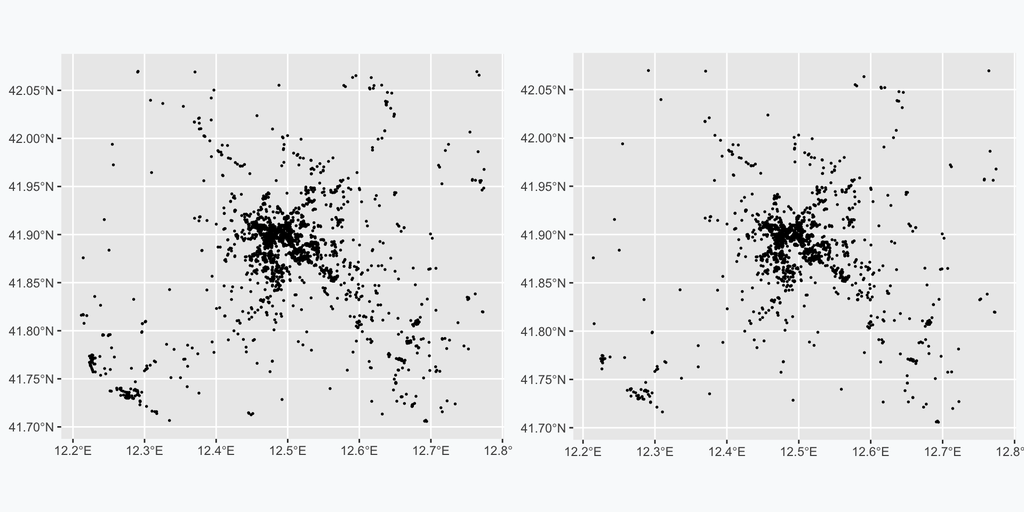

## Subsetting based on attributes

Subsetting columns is very similar to subsetting a dataframe.

The difference is the geometry column that stays.

We turn the spatial dataframe into a regular dataframe.

```r
df3<-st_drop_geometry(df2)
```

## Subsetting based on attributes

This is how the two compare:

```r
head(df2, n=3)
```

```
Simple feature collection with 3 features and 2 fields
Geometry type: POINT
Dimension:     XY
Bounding box:  xmin: 12.4737 ymin: 41.88826 xmax: 12.49948 ymax: 41.8958
Geodetic CRS:  WGS 84
                           name                 addr.street
1             Pizzeria ai Marmi         Viale di Trastevere
2                 Sichuan Haozi Via di San Martino ai Monti
3 Dar filettaro a Santa Barbara           Largo dei Librari
                   geometry
1 POINT (12.47379 41.88826)
2  POINT (12.49948 41.8958)
3  POINT (12.4737 41.89467)
```

```r
head(df3, n=3)
```

```
                           name                 addr.street
1             Pizzeria ai Marmi         Viale di Trastevere
2                 Sichuan Haozi Via di San Martino ai Monti
3 Dar filettaro a Santa Barbara           Largo dei Librari
```

## Reading vector layers

As discussed, the most common vector files are:

| **Type** | **Format** | **File extension** |
| --- | --- | --- |
| Binary | ESRI Shapefile | `.shp`, `.shx`, `.dbf`, `.prj` |
|  | GeoPackage (GPKG) | `.gpkg` |
| Plain Text | GeoJSON | `.json` or `.geojson` |
|  | GPS Exchange Format (GPX) | `.gpx` |
|  | Keyhole Markup Language (KML) | `.kml` |
| Spatial Databases | PostgreSQL / PostGIS |  |

## Reading vector layers

Please download the following [US spatial files](https://www.dropbox.com/scl/fo/ujl7r339mlfy3itzh1ch8/h?rlkey=7kiyq4zs40n4w8su84ary5n6d&dl=0)

Place them in your week’s folder.

## Reading vector layers

Here is how we would read all these different files:

Reading a shape file

```r
usa_cntry <- st_read(dsn="./data/gadm41_USA_shp/gadm41_USA_0.shp", quiet = TRUE)
```

## Reading vector layers

Reading a geojson file

```r
usa_cntry = st_read('data/usa_database/geojson/gadm41_USA_0.geojson', quiet = TRUE)
```

## Reading vector layers

Reading from a geodatabase

```r
usa_cntry <- st_read(dsn="./data/usa_database/usa_geodatabase.gdb",layer="gadm41_USA_0", quiet = TRUE)
```

## Mapping the files

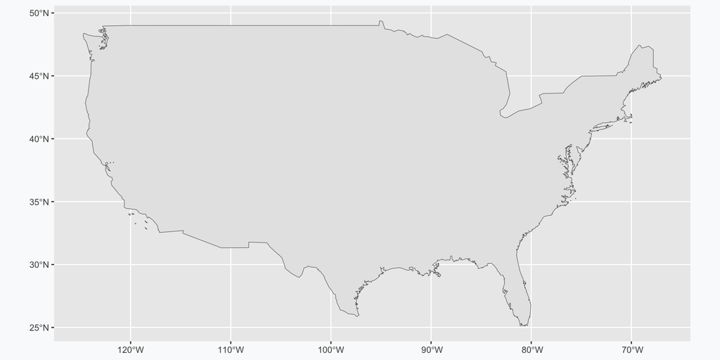

## What Have We Learned?

- Loaded and mapped **shapefiles** for countries and their subdivisions
- Compared common **vector file formats** and read them with `st_read`
- Built geometries, geometry columns, and full **`sf` layers**
- Used **EPSG codes** to set coordinate reference systems
- Created point layers **from tables** and subset them by attributes

Next: spatial operations — joins, buffers, and intersections in `sf`.